# R Notebook

```r
library(DescTools)
```

The following set of data values was obtained from a study of people’s perceptions on whether the color of a person’s clothing is related to how intelligent the person looks. The subjects rated the person’s intelligence on a scale of 1 to 10. Randomly selected group 1 subjects were shown people with clothing in shades of blue and gray. Randomly selected group 2 subjects were shown people with clothing in shades of brown and yellow. Randomly selected group 3 subjects were shown people with clothing in shades of pink and orange. The results follow.

```r
Group_1 <- c(8, 7, 7, 7, 8, 8, 6, 8, 8, 7, 7, 8, 8)
Group_2 <- c(7, 8, 7, 7, 5, 8, 5, 8, 7, 6, 6, 6, 6)
Group_3 <- c(4, 9, 6, 7, 9, 8, 5, 8, 7, 5, 4, 5, 4)

data <- data.frame(Group_1, Group_2, Group_3)
print(data)
```

| Group_1 | Group_2 | Group_3 |
| --- | --- | --- |
| 8 | 7 | 4 |
| 7 | 8 | 9 |
| 7 | 7 | 6 |
| 7 | 7 | 7 |
| 8 | 5 | 9 |
| 8 | 8 | 8 |
| 6 | 5 | 5 |
| 8 | 8 | 8 |
| 8 | 7 | 7 |
| 7 | 6 | 5 |

[output cut: 3 more lines]

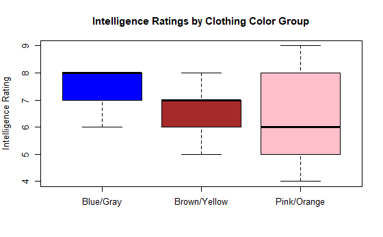

```r
boxplot(data, main = "Intelligence Ratings by Clothing Color Group",
        col = c("blue", "brown", "pink"),
        names = c("Blue/Gray", "Brown/Yellow", "Pink/Orange"),
        ylab = "Intelligence Rating")
```

The box plot displays intelligence ratings categorized by clothing color groups: Blue/Gray, Brown/Yellow, and Pink/Orange. The Blue/Gray group has the highest median intelligence rating with relatively low variation. The Brown/Yellow group has a slightly lower median and a moderate spread in ratings. The Pink/Orange group, however, shows the most variation, with ratings ranging from very high to very low. This suggests that while some individuals rated this group highly, others rated it quite low, leading to greater inconsistency in perception.

```r
group_means <- colMeans(data)
overall_mean <- mean(unlist(data))

print("Group Means:")
```

```
[1] "Group Means:"
```

```r
print(group_means)
```

```
 Group_1  Group_2  Group_3
7.461538 6.615385 6.230769
```

```r
cat("\nOverall Mean:", round(overall_mean, 2))
```

```
Overall Mean: 6.77
```

```r
barplot(group_means, col = c("blue", "brown", "pink"),
        names.arg = c("Blue/Gray", "Brown/Yellow", "Pink/Orange"),
        main = "Average Intelligence Ratings",
        ylab = "Mean Rating",
        ylim = c(0, max(group_means) + 1))  # Adjust y-axis for mean line

abline(h = overall_mean, col = "red", lwd = 2, lty = 2)
```

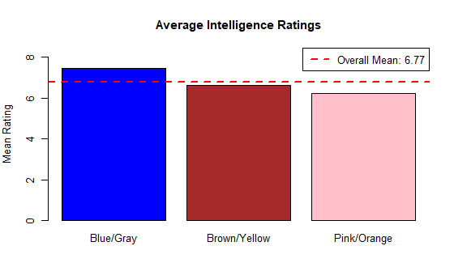

```r
legend("topright", legend = paste("Overall Mean:", round(overall_mean, 2)), col = "red", lwd = 2, lty = 2)
```

```r
data_long <- data.frame(
  value = c(Group_1, Group_2, Group_3),
  group = factor(rep(c("Group_1", "Group_2", "Group_3"), each = length(Group_1)))
)
```

```r
anova_result <- aov(value ~ group, data = data_long)

critical_value <- qf(0.95, df1 = 2, df2 = length(data_long$value) - 3)

summary(anova_result)
```

```
            Df Sum Sq Mean Sq F value Pr(>F)
group        2  10.31   5.154   3.061 0.0592 .
Residuals   36  60.62   1.684
---
Signif. codes:  0 ‘***’ 0.001 ‘**’ 0.01 ‘*’ 0.05 ‘.’ 0.1 ‘ ’ 1
```

```r
print(paste("Critical F-value:", critical_value))
```

```
[1] "Critical F-value: 3.25944630614411"
```

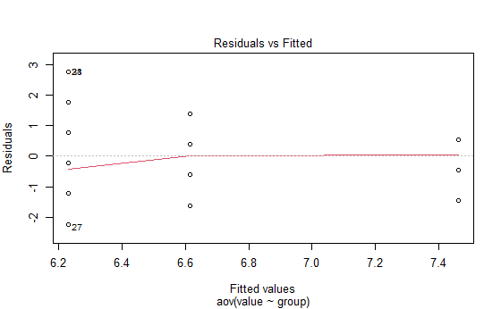

```r
plot(anova_result, 1)
```

The ANOVA results indicate that there is no strong statistical evidence to suggest a significant difference between the means of the three groups. The F-value of **3.061** is slightly below the critical F-value of **3.2594**, and the p-value of **0.0592** is slightly above the common significance threshold of **0.05**. This means that, at a **95% confidence level**, we fail to reject the null hypothesis, implying that any observed differences in group means could be due to random variation rather than a true effect. However, since the p-value is close to 0.05, the results are marginal, and further investigation, such as increasing the sample size or conducting post hoc tests like **TukeyHSD**, may help determine if there are meaningful differences between specific groups.

```r
scheffe <- ScheffeTest(anova_result)
scheffe
```

```
  Posthoc multiple comparisons of means: Scheffe Test
    95% family-wise confidence level

$group
                      diff    lwr.ci     upr.ci   pval
Group_2-Group_1 -0.8461538 -2.145636 0.45332860 0.2641
Group_3-Group_1 -1.2307692 -2.530252 0.06871322 0.0666 .
Group_3-Group_2 -0.3846154 -1.684098 0.91486706 0.7533

---
Signif. codes:  0 '***' 0.001 '**' 0.01 '*' 0.05 '.' 0.1 ' ' 1
```

The **Scheffé Test** results indicate that there are no statistically significant differences between the group means at a **95% confidence level**. Each pairwise comparison shows a **p-value greater than 0.05**, meaning we fail to reject the null hypothesis and conclude that any differences could be due to random variation. However, the **Group_3 vs. Group_1** comparison has a **p-value of 0.0666**, which is close to the significance threshold, suggesting a marginal difference that may warrant further investigation. Additionally, all confidence intervals include **zero**, further supporting the lack of strong evidence for significant differences.

### **Key Observations:**

- **No significant differences**: All **p-values > 0.05**, indicating no statistically significant mean differences.
- **Marginal difference between Group_3 and Group_1**: The p-value **(0.0666)** is close to 0.05, suggesting a slight but **not statistically significant** difference.
- **Confidence intervals contain zero**: This means that the actual mean difference could be **zero**, reinforcing the conclusion that the differences are not significant.
- **Aligns with ANOVA results**: The Scheffé Test supports the previous ANOVA findings, which also showed no strong evidence of significant differences.

### **Conclusion:**

The results suggest that there is **no strong statistical evidence** of differences between the group means. However, the near-significance of **Group_3 vs. Group_1** suggests that further analysis, such as increasing the sample size or using a more sensitive post hoc test like **TukeyHSD**, might provide more clarity.

```r
tukey <- TukeyHSD(anova_result, conf.level = .95)
tukey
```

```
  Tukey multiple comparisons of means
    95% family-wise confidence level

Fit: aov(formula = value ~ group, data = data_long)

$group
                      diff       lwr       upr     p adj
Group_2-Group_1 -0.8461538 -2.090203 0.3978952 0.2333852
Group_3-Group_1 -1.2307692 -2.474818 0.0132798 0.0529974
Group_3-Group_2 -0.3846154 -1.628664 0.8594336 0.7321727
```

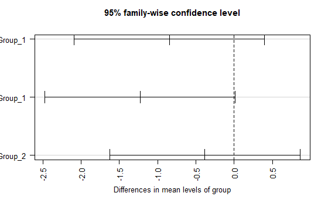

```r
plot(tukey, las = 2)
```

The **Tukey HSD Test** results provide pairwise comparisons between the group means while controlling for family-wise error at a **95% confidence level**. The analysis confirms that there are **no statistically significant differences** among the groups, as all adjusted p-values (**p adj**) are greater than **0.05**.

### **Key Observations:**

- **No significant differences**: All **p-values > 0.05**, meaning no strong statistical evidence supports a difference between the groups.
- **Group_3 vs. Group_1 shows the lowest p-value (0.0529974)**: This is very close to 0.05, suggesting a **marginally significant difference**, but it still does not meet the strict threshold.
- **Confidence intervals include zero**: Since the lower (**lwr**) and upper (**upr**) bounds contain zero, it suggests that the true mean difference **could be zero**, reinforcing the conclusion of no significant differences.
- **Consistent with ANOVA and Scheffé Test**: These results align with the previous tests, confirming that any differences in means are likely due to random variation rather than a meaningful effect.

### **Conclusion:**

The **Tukey HSD Test** supports the finding that the group means do not significantly differ. However, the **Group_3 vs. Group_1 comparison is borderline**, suggesting that a **larger sample size or further testing** could help clarify whether a meaningful difference exists.

### **Answers to the Questions:**

2. **What is the purpose of this study?**

The purpose of this study is to compare the means of multiple groups to determine if there are significant differences between them.

4. **Are there contradictions in the results?**
   - Based on the previous analyses, the **ANOVA test** indicated that there is **no significant difference** between the groups overall (**p = 0.0592**, which is above 0.05).
   - The **Scheffé test** also showed **no significant differences** among the groups, as all **p-values > 0.05**.
   - The **Tukey test** results were consistent with ANOVA and Scheffé, confirming no significant differences.
   - Since all methods show **no strong evidence of differences**, there are **no contradictions** in the results.
5. **When would Tukey’s test be preferred over the Scheffé method?**
   - **Tukey’s test** is preferred when the study is focused only on **pairwise comparisons** and when **sample sizes are equal** because it provides a more powerful test in such cases.
   - **Scheffé’s test** is more conservative and is better suited for situations where **all possible contrasts** (not just pairwise comparisons) need to be tested, making it ideal for **exploratory research** where multiple comparisons may be required.
   - If the goal is to identify **which specific groups differ**, Tukey’s test is more appropriate. However, if the focus is on a **broader set of comparisons**, including **custom contrasts**, Scheffé’s test is a better choice.